# BIB Revision — Supplementary Analysis

# EOPE — HELLP syndrome (T3) (Fig 4D, cx)

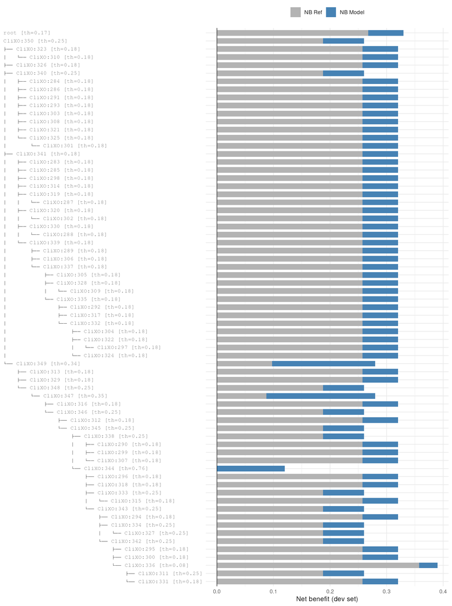

**Figure 21.** Net benefit of model vs. reference at selected thresholds — EOPE — HELLP syndrome (T3) (Fig 4D, cx).

Table 22. Confusion matrices — EOPE — HELLP syndrome (T3) (Fig 4D, cx).

| Ontology | PPV/TPR (Dev) | PPV/TPR (Test) | NPV/TNR (Dev) | NPV/TNR (Test) | C1 | C2 | C3 | C4 | Reported |
| --- | --- | --- | --- | --- | --- | --- | --- | --- | --- |
| root (GPR146†, SUV39H1, PIK3CB, CORO2A, BASP1, DLX5, SFXN3, SLC6A8, ZMYND8, SEMA4C, LRRC8A, CNNM4, HEY1, SEC23A, MIDN, EAF1, ERRFI1, PFKFB4, SLC2A1, VWCE, ANKRD37, ITGA5, GALK1, FANCE, MME, PPL, SWAP7… | 70.7% (68.1, 73.2) / 81.8% (79.5, 84.0) | 2.5% (1.8, 3.1) / — | 83.3% (80.9, 85.7) / 72.8% (70.1, 75.5) | 100.0% (100.0, 100.0) / 61.1% (60.0, 62.2) | \|✓ | \|✓ | ✓ | ✓ | root |
| CliXO:350 (GPR146, SUV39H1, PIK3CB, CORO2A, BASP1, DLX5, SFXN3, SLC6A8, ZMYND8, SEMA4C, LRRC8A, CNNM4, HEY1, SEC23A, MIDN, EAF1, ERRFI1, PFKFB4, SLC2A1, VWCE, ANKRD37, ITGA5, GALK1, FANCE, MME, PPL, S… | 44.2% (42.0, 46.3) / 100.0% (100.0, 100.0) | 1.0% (0.7, 1.2) / — | — / 0.0% (0.0, 0.0) | — / 0.0% (0.0, 0.0) | \| | \| |  | ✓ |  |
| ├── CliXO:323 (AMOT, ZFAT, IDE, MAT2A, ASAH1, TSPAN3, ATXN10) | 44.2% (42.0, 46.3) / 100.0% (100.0, 100.0) | 1.0% (0.7, 1.2) / — | — / 0.0% (0.0, 0.0) | — / 0.0% (0.0, 0.0) | \| | \| |  |  |  |
| │ └── CliXO:310 (AMOT, ZFAT, MAT2A) | 44.2% (42.0, 46.3) / 100.0% (100.0, 100.0) | 1.0% (0.7, 1.2) / — | — / 0.0% (0.0, 0.0) | — / 0.0% (0.0, 0.0) | \| | \| |  |  |  |
| ├── CliXO:326 (CORO2A, TSC22D1, MBNL2, ZNF143, HMGB3, LYN, FEM1B, BTBD10, LIMCH1, LRRC1) | 44.2% (42.0, 46.3) / 100.0% (100.0, 100.0) | 1.0% (0.7, 1.2) / — | — / 0.0% (0.0, 0.0) | — / 0.0% (0.0, 0.0) | \| | \| |  |  |  |
| ├── CliXO:340 (PIK3CB, BASP1, DLX5, SLC6A8, ZMYND8, SEMA4C, CNNM4, ERRFI1, PFKFB4, GALK1, FANCE, MME, SWAP70, CYP2J2, MOB3A, SEMA4B, FBLIM1, SLC16A3, TPP1, GREM2, PIK3R1, SMIM3, GLA, EPHB3, SIPA1L1, C… | 44.2% (42.0, 46.3) / 100.0% (100.0, 100.0) | 1.0% (0.7, 1.2) / — | — / 0.0% (0.0, 0.0) | — / 0.0% (0.0, 0.0) | \| | \| |  |  |  |
| │ ├── CliXO:284 (PODXL, GPX3) | 44.2% (42.0, 46.3) / 100.0% (100.0, 100.0) | 1.0% (0.7, 1.2) / — | — / 0.0% (0.0, 0.0) | — / 0.0% (0.0, 0.0) | \| | \| |  |  |  |
| │ ├── CliXO:286 (BCORL1, WNK2) | 44.2% (42.0, 46.3) / 100.0% (100.0, 100.0) | 1.0% (0.7, 1.2) / — | — / 0.0% (0.0, 0.0) | — / 0.0% (0.0, 0.0) | \| | \| |  |  |  |
| │ ├── CliXO:291 (EPS8L1, SHANK2) | 44.2% (42.0, 46.3) / 100.0% (100.0, 100.0) | 1.0% (0.7, 1.2) / — | — / 0.0% (0.0, 0.0) | — / 0.0% (0.0, 0.0) | \| | \| |  |  |  |
| │ ├── CliXO:293 (DPP7, GPX3) | 44.2% (42.0, 46.3) / 100.0% (100.0, 100.0) | 1.0% (0.7, 1.2) / — | — / 0.0% (0.0, 0.0) | — / 0.0% (0.0, 0.0) | \| | \| |  |  |  |
| │ ├── CliXO:303 (VEGFA, CRISPLD2) | 44.2% (42.0, 46.3) / 100.0% (100.0, 100.0) | 1.0% (0.7, 1.2) / — | — / 0.0% (0.0, 0.0) | — / 0.0% (0.0, 0.0) | \| | \| |  |  |  |
| │ ├── CliXO:308 (TPP1, GORASP2, GGCX) | 44.2% (42.0, 46.3) / 100.0% (100.0, 100.0) | 1.0% (0.7, 1.2) / — | — / 0.0% (0.0, 0.0) | — / 0.0% (0.0, 0.0) | \| | \| |  |  |  |
| │ ├── CliXO:321 (IGSF8, TIMP3, ZDHHC9, PREP, SLC26A6, LDLR) | 44.2% (42.0, 46.3) / 100.0% (100.0, 100.0) | 1.0% (0.7, 1.2) / — | — / 0.0% (0.0, 0.0) | — / 0.0% (0.0, 0.0) | \| | \| |  |  |  |
| │ └── CliXO:325 (GLA, AMOT, PREP, SLC26A6, SLC25A4, WDFY2, LDLR, CEBPD, FAM43A) | 44.2% (42.0, 46.3) / 100.0% (100.0, 100.0) | 1.0% (0.7, 1.2) / — | — / 0.0% (0.0, 0.0) | — / 0.0% (0.0, 0.0) | \| | \| |  |  |  |
| │ └── CliXO:301 (AMOT, LDLR) | 44.2% (42.0, 46.3) / 100.0% (100.0, 100.0) | 1.0% (0.7, 1.2) / — | — / 0.0% (0.0, 0.0) | — / 0.0% (0.0, 0.0) | \| | \| |  |  |  |
| ├── CliXO:341 (IL36RN, HSPA9, PIGX, TM9SF3, TSPAN12, GCLM, PLCXD2, ZFAT, KIF5B, CLTC, SPG21, RPL15, ZC2HC1A, PHTF2, MBNL2, NUFIP2, RSU1, IQGAP2, SUMO3, CREB1, FRZB, TXNRD1, MOB3C, TAF9B, PFKM, PAWR, M… | 44.2% (42.0, 46.3) / 100.0% (100.0, 100.0) | 1.0% (0.7, 1.2) / — | — / 0.0% (0.0, 0.0) | — / 0.0% (0.0, 0.0) | \| | \| |  |  |  |
| │ ├── CliXO:283 (SPG21, RSU1) | 44.2% (42.0, 46.3) / 100.0% (100.0, 100.0) | 1.0% (0.7, 1.2) / — | — / 0.0% (0.0, 0.0) | — / 0.0% (0.0, 0.0) | \| | \| |  |  |  |
| │ ├── CliXO:285 (PFKM, SPON1) | 44.2% (42.0, 46.3) / 100.0% (100.0, 100.0) | 1.0% (0.7, 1.2) / — | — / 0.0% (0.0, 0.0) | — / 0.0% (0.0, 0.0) | \| | \| |  |  |  |
| │ ├── CliXO:298 (SUMO3, SLC23A2) | 44.2% (42.0, 46.3) / 100.0% (100.0, 100.0) | 1.0% (0.7, 1.2) / — | — / 0.0% (0.0, 0.0) | — / 0.0% (0.0, 0.0) | \| | \| |  |  |  |
| │ ├── CliXO:314 (IL36RN, PLCXD2, PDE5A, PIP5K1B) | 44.2% (42.0, 46.3) / 100.0% (100.0, 100.0) | 1.0% (0.7, 1.2) / — | — / 0.0% (0.0, 0.0) | — / 0.0% (0.0, 0.0) | \| | \| |  |  |  |
| │ ├── CliXO:319 (FEM1B, BTBD10, ARHGAP5, ADK, ZFR, CASD1) | 44.2% (42.0, 46.3) / 100.0% (100.0, 100.0) | 1.0% (0.7, 1.2) / — | — / 0.0% (0.0, 0.0) | — / 0.0% (0.0, 0.0) | \| | \| |  |  |  |
| │ │ └── CliXO:287 (BTBD10, ADK) | 44.2% (42.0, 46.3) / 100.0% (100.0, 100.0) | 1.0% (0.7, 1.2) / — | — / 0.0% (0.0, 0.0) | — / 0.0% (0.0, 0.0) | \| | \| |  |  |  |
| │ ├── CliXO:320 (MBNL2, PIP5K1B, ZNF462, ZFR, RANBP6, ZMYM4) | 44.2% (42.0, 46.3) / 100.0% (100.0, 100.0) | 1.0% (0.7, 1.2) / — | — / 0.0% (0.0, 0.0) | — / 0.0% (0.0, 0.0) | \| | \| |  |  |  |
| │ │ └── CliXO:302 (MBNL2, ZNF462) | 44.2% (42.0, 46.3) / 100.0% (100.0, 100.0) | 1.0% (0.7, 1.2) / — | — / 0.0% (0.0, 0.0) | — / 0.0% (0.0, 0.0) | \| | \| |  |  |  |
| │ ├── CliXO:330 (TM9SF3, SPG21, ZC2HC1A, PHTF2, ANXA1, RNF20, C9orf72, BTBD10, ZFR, RANBP6, SACM1L, CYP19A1, AZIN1, ZNF75A, AK2, NHLRC2, ZMYND11) | 44.2% (42.0, 46.3) / 100.0% (100.0, 100.0) | 1.0% (0.7, 1.2) / — | — / 0.0% (0.0, 0.0) | — / 0.0% (0.0, 0.0) | \| | \| |  |  |  |
| │ │ └── CliXO:288 (ZNF75A, ZMYND11) | 44.2% (42.0, 46.3) / 100.0% (100.0, 100.0) | 1.0% (0.7, 1.2) / — | — / 0.0% (0.0, 0.0) | — / 0.0% (0.0, 0.0) | \| | \| |  |  |  |
| │ └── CliXO:339 (HSPA9, PIGX, TM9SF3, GCLM, PLCXD2, ZFAT, KIF5B, CLTC, SPG21, RPL15, ZC2HC1A, PHTF2, NUFIP2, IQGAP2, CREB1, FRZB, TXNRD1, TAF9B, PAWR, MTMR6, IGF1, MUC15, IDE, CCND1, MAP4K4, PCCB, CLD… | 44.2% (42.0, 46.3) / 100.0% (100.0, 100.0) | 1.0% (0.7, 1.2) / — | — / 0.0% (0.0, 0.0) | — / 0.0% (0.0, 0.0) | \| | \| |  |  |  |
| │ ├── CliXO:289 (NMNAT2, VWA5A) | 44.2% (42.0, 46.3) / 100.0% (100.0, 100.0) | 1.0% (0.7, 1.2) / — | — / 0.0% (0.0, 0.0) | — / 0.0% (0.0, 0.0) | \| | \| |  |  |  |
| │ ├── CliXO:306 (SPG21, TAF9B, FBXO8) | 44.2% (42.0, 46.3) / 100.0% (100.0, 100.0) | 1.0% (0.7, 1.2) / — | — / 0.0% (0.0, 0.0) | — / 0.0% (0.0, 0.0) | \| | \| |  |  |  |
| │ └── CliXO:337 (HSPA9, PIGX, TM9SF3, GCLM, PLCXD2, ZFAT, KIF5B, CLTC, SPG21, RPL15, ZC2HC1A, PHTF2, NUFIP2, IQGAP2, CREB1, FRZB, TAF9B, PAWR, MTMR6, IGF1, MUC15, IDE, CCND1, MAP4K4, PCCB, CLDN16, PKD… | 44.2% (42.0, 46.3) / 100.0% (100.0, 100.0) | 1.0% (0.7, 1.2) / — | — / 0.0% (0.0, 0.0) | — / 0.0% (0.0, 0.0) | \| | \| |  |  |  |
| │ ├── CliXO:305 (HSPA9, ATXN10, RBBP4) | 44.2% (42.0, 46.3) / 100.0% (100.0, 100.0) | 1.0% (0.7, 1.2) / — | — / 0.0% (0.0, 0.0) | — / 0.0% (0.0, 0.0) | \| | \| |  |  |  |
| │ ├── CliXO:328 (GCLM, PLCXD2, ZC2HC1A, PHTF2, PAWR, CCND1, PCCB, MAT2A, PRKAR1A, PDE5A, STXBP6, CD28, KLHL42, FBN2, CYBB) | 44.2% (42.0, 46.3) / 100.0% (100.0, 100.0) | 1.0% (0.7, 1.2) / — | — / 0.0% (0.0, 0.0) | — / 0.0% (0.0, 0.0) | \| | \| |  |  |  |
| │ │ └── CliXO:309 (PLCXD2, PAWR, PDE5A) | 44.2% (42.0, 46.3) / 100.0% (100.0, 100.0) | 1.0% (0.7, 1.2) / — | — / 0.0% (0.0, 0.0) | — / 0.0% (0.0, 0.0) | \| | \| |  |  |  |
| │ └── CliXO:335 (PIGX, TM9SF3, GCLM, PLCXD2, KIF5B, CLTC, SPG21, RPL15, ZC2HC1A, PHTF2, NUFIP2, IQGAP2, CREB1, TAF9B, PAWR, MTMR6, IGF1, IDE, CCND1, CLDN16, PKD2, ASAH1, C9orf72, PRKAR1A, MRS2, PDE5A,… | 44.2% (42.0, 46.3) / 100.0% (100.0, 100.0) | 1.0% (0.7, 1.2) / — | — / 0.0% (0.0, 0.0) | — / 0.0% (0.0, 0.0) | \| | \| |  |  |  |
| │ ├── CliXO:292 (KIF5B, MTMR6) | 44.2% (42.0, 46.3) / 100.0% (100.0, 100.0) | 1.0% (0.7, 1.2) / — | — / 0.0% (0.0, 0.0) | — / 0.0% (0.0, 0.0) | \| | \| |  |  |  |
| │ ├── CliXO:317 (CCND1, IL33, EXOC6, STXBP6, MXRA5) | 44.2% (42.0, 46.3) / 100.0% (100.0, 100.0) | 1.0% (0.7, 1.2) / — | — / 0.0% (0.0, 0.0) | — / 0.0% (0.0, 0.0) | \| | \| |  |  |  |
| │ └── CliXO:332 (TM9SF3, GCLM, CLTC, RPL15, ZC2HC1A, NUFIP2, IGF1, IDE, PKD2, ASAH1, MRS2, SPRED1, PIP5K1B, CYB561A3, ATXN10, HPGDS, FAM20B, WDR11, SLC23A2, HNMT, ZEB2, AZIN1, CD28, SPON1, TLR7, KLHL4… | 44.2% (42.0, 46.3) / 100.0% (100.0, 100.0) | 1.0% (0.7, 1.2) / — | — / 0.0% (0.0, 0.0) | — / 0.0% (0.0, 0.0) | \| | \| |  |  |  |
| │ ├── CliXO:304 (IGF1, ZEB2) | 44.2% (42.0, 46.3) / 100.0% (100.0, 100.0) | 1.0% (0.7, 1.2) / — | — / 0.0% (0.0, 0.0) | — / 0.0% (0.0, 0.0) | \| | \| |  |  |  |
| │ ├── CliXO:322 (SPRED1, HPGDS, HNMT, ZEB2, CD28, TLR7, CYBB) | 44.2% (42.0, 46.3) / 100.0% (100.0, 100.0) | 1.0% (0.7, 1.2) / — | — / 0.0% (0.0, 0.0) | — / 0.0% (0.0, 0.0) | \| | \| |  |  |  |
| │ │ └── CliXO:297 (SPRED1, CD28) | 44.2% (42.0, 46.3) / 100.0% (100.0, 100.0) | 1.0% (0.7, 1.2) / — | — / 0.0% (0.0, 0.0) | — / 0.0% (0.0, 0.0) | \| | \| |  |  |  |
| │ └── CliXO:324 (TM9SF3, PKD2, ASAH1, PIP5K1B, FAM20B, KLHL42, PLPP3, FBN2) | 44.2% (42.0, 46.3) / 100.0% (100.0, 100.0) | 1.0% (0.7, 1.2) / — | — / 0.0% (0.0, 0.0) | — / 0.0% (0.0, 0.0) | \| | \| |  |  |  |
| └── CliXO:349 (GPR146, SUV39H1, PIK3CB, CORO2A, BASP1, DLX5, SFXN3, SLC6A8, ZMYND8, SEMA4C, LRRC8A, CNNM4, HEY1, SEC23A, MIDN, EAF1, ERRFI1, PFKFB4, SLC2A1, VWCE, ANKRD37, ITGA5, GALK1, FANCE, MME, PP… | 70.7% (68.1, 73.2) / 81.8% (79.5, 84.0) | 2.5% (1.8, 3.1) / — | 83.3% (80.9, 85.7) / 72.8% (70.1, 75.5) | 100.0% (100.0, 100.0) / 61.1% (60.0, 62.2) | \|✓ | \|✓ |  | ✓ | root |
| ├── CliXO:313 (FBLIM1, EPS8L2, MAP3K9, LRRFIP2) | 44.2% (42.0, 46.3) / 100.0% (100.0, 100.0) | 1.0% (0.7, 1.2) / — | — / 0.0% (0.0, 0.0) | — / 0.0% (0.0, 0.0) | \| | \| |  |  |  |
| ├── CliXO:329 (ZMYND8, HEY1, SLC2A1, PPL, CYP2J2, SMIM3, AFMID, PIP5KL1, INPP5B, FCN3, SCARB1, PRKCH, PODXL, VEGFC, NOD1, GPX3) | 44.2% (42.0, 46.3) / 100.0% (100.0, 100.0) | 1.0% (0.7, 1.2) / — | — / 0.0% (0.0, 0.0) | — / 0.0% (0.0, 0.0) | \| | \| |  |  |  |
| └── CliXO:348 (GPR146, SUV39H1, PIK3CB, CORO2A, BASP1, DLX5, SFXN3, SLC6A8, ZMYND8, SEMA4C, LRRC8A, CNNM4, HEY1, SEC23A, MIDN, EAF1, ERRFI1, PFKFB4, SLC2A1, VWCE, ANKRD37, ITGA5, GALK1, FANCE, MME, PP… | 44.2% (42.0, 46.3) / 100.0% (100.0, 100.0) | 1.0% (0.7, 1.2) / — | — / 0.0% (0.0, 0.0) | — / 0.0% (0.0, 0.0) | \| | \| |  |  | root |
| └── CliXO:347 (GPR146, SUV39H1, PIK3CB, CORO2A, BASP1, DLX5, SFXN3, SLC6A8, ZMYND8, SEMA4C, LRRC8A, CNNM4, HEY1, SEC23A, MIDN, EAF1, ERRFI1, PFKFB4, SLC2A1, VWCE, ANKRD37, ITGA5, GALK1, FANCE, MME, PP… | 70.7% (68.1, 73.2) / 81.8% (79.5, 84.0) | 2.5% (1.8, 3.1) / — | 83.3% (80.9, 85.7) / 72.8% (70.1, 75.5) | 100.0% (100.0, 100.0) / 61.1% (60.0, 62.2) | \|✓ | \|✓ |  | ✓ | root |
| ├── CliXO:316 (EPS8L2, ARID3A, BCORL1, WNK2, CDK9) | 44.2% (42.0, 46.3) / 100.0% (100.0, 100.0) | 1.0% (0.7, 1.2) / — | — / 0.0% (0.0, 0.0) | — / 0.0% (0.0, 0.0) | \| | \| |  |  |  |
| └── CliXO:346 (GPR146, SUV39H1, PIK3CB, CORO2A, BASP1, DLX5, SFXN3, SLC6A8, ZMYND8, SEMA4C, LRRC8A, CNNM4, HEY1, SEC23A, MIDN, EAF1, ERRFI1, PFKFB4, SLC2A1, VWCE, ANKRD37, ITGA5, GALK1, FANCE, MME, PP… | 44.2% (42.0, 46.3) / 100.0% (100.0, 100.0) | 1.0% (0.7, 1.2) / — | — / 0.0% (0.0, 0.0) | — / 0.0% (0.0, 0.0) | \| | \| |  |  | root |
| ├── CliXO:312 (TMEM45A, APH1B, VEGFA, CRISPLD2) | 44.2% (42.0, 46.3) / 100.0% (100.0, 100.0) | 1.0% (0.7, 1.2) / — | — / 0.0% (0.0, 0.0) | — / 0.0% (0.0, 0.0) | \| | \| |  |  |  |
| └── CliXO:345 (GPR146, SUV39H1, PIK3CB, CORO2A, BASP1, DLX5, SFXN3, SLC6A8, ZMYND8, SEMA4C, LRRC8A, CNNM4, HEY1, SEC23A, MIDN, EAF1, ERRFI1, PFKFB4, SLC2A1, VWCE, ANKRD37, ITGA5, GALK1, FANCE, MME, PP… | 44.2% (42.0, 46.3) / 100.0% (100.0, 100.0) | 1.0% (0.7, 1.2) / — | — / 0.0% (0.0, 0.0) | — / 0.0% (0.0, 0.0) | \| | \| |  | ✓ | root |
| ├── CliXO:338 (GPR146, PIK3CB, DLX5, SFXN3, SEMA4C, LRRC8A, EAF1, PFKFB4, VWCE, ITGA5, GALK1, MME, CYP2J2, MOB3A, SEMA4B, ALKBH5, C4orf3, SPAG4, SLC16A3, NECTIN4, EPS8L2, GREM2, KLF4, DNAJC1, GLA, NPE… | 44.2% (42.0, 46.3) / 100.0% (100.0, 100.0) | 1.0% (0.7, 1.2) / — | — / 0.0% (0.0, 0.0) | — / 0.0% (0.0, 0.0) | \| | \| |  | ✓ |  |
| │ ├── CliXO:290 (GLA, BTD) | 44.2% (42.0, 46.3) / 100.0% (100.0, 100.0) | 1.0% (0.7, 1.2) / — | — / 0.0% (0.0, 0.0) | — / 0.0% (0.0, 0.0) | \| | \| |  |  |  |
| │ ├── CliXO:299 (PLOD2, P4HA1) | 44.2% (42.0, 46.3) / 100.0% (100.0, 100.0) | 1.0% (0.7, 1.2) / — | — / 0.0% (0.0, 0.0) | — / 0.0% (0.0, 0.0) | \| | \| |  |  |  |
| │ └── CliXO:307 (INHA, FKBP8, GALE) | 44.2% (42.0, 46.3) / 100.0% (100.0, 100.0) | 1.0% (0.7, 1.2) / — | — / 0.0% (0.0, 0.0) | — / 0.0% (0.0, 0.0) | \| | \| |  |  |  |
| └── CliXO:344 (GPR146, SUV39H1, PIK3CB, CORO2A, BASP1, DLX5, SFXN3, SLC6A8, ZMYND8, SEMA4C, LRRC8A, CNNM4, HEY1, SEC23A, MIDN, EAF1, ERRFI1, PFKFB4, SLC2A1, VWCE, ANKRD37, ITGA5, GALK1, FANCE, MME, PP… | 86.6% (84.2, 89.0) / 52.2% (49.1, 55.3) | — / — | 71.2% (69.0, 73.3) / 93.4% (92.0, 94.9) | 99.0% (98.8, 99.3) / 100.0% (100.0, 100.0) | \|✓ | \| |  | ✓ | root |
| ├── CliXO:296 (NEK11, ASTE1) | 44.2% (42.0, 46.3) / 100.0% (100.0, 100.0) | 1.0% (0.7, 1.2) / — | — / 0.0% (0.0, 0.0) | — / 0.0% (0.0, 0.0) | \| | \| |  |  |  |
| ├── CliXO:318 (ANKRD37, PLIN2, MAP3K8, BHLHE40, NFIL3, ARRDC3) | 44.2% (42.0, 46.3) / 100.0% (100.0, 100.0) | 1.0% (0.7, 1.2) / — | — / 0.0% (0.0, 0.0) | — / 0.0% (0.0, 0.0) | \| | \| |  |  |  |
| ├── CliXO:333 (PIK3CB, SLC6A8, SEMA4C, LRRC8A, VWCE, ITGA5, GALK1, FANCE, MOB3A, FBLIM1, ALKBH5, EFNB1, KRT19, GUCA2A, SPAG4, TPP1, TMEM45A, IGSF8, ENG, FLNB, FSTL3, INHA, GDPD3, P4HA1, CYB5R1, DPP7, … | 44.2% (42.0, 46.3) / 100.0% (100.0, 100.0) | 1.0% (0.7, 1.2) / — | — / 0.0% (0.0, 0.0) | — / 0.0% (0.0, 0.0) | \| | \| |  |  |  |
| │ └── CliXO:315 (SLC6A8, VWCE, GALK1, SPAG4) | 44.2% (42.0, 46.3) / 100.0% (100.0, 100.0) | 1.0% (0.7, 1.2) / — | — / 0.0% (0.0, 0.0) | — / 0.0% (0.0, 0.0) | \| | \| |  |  |  |
| └── CliXO:343 (GPR146, SUV39H1, PIK3CB, CORO2A, BASP1, DLX5, SFXN3, SLC6A8, ZMYND8, SEMA4C, LRRC8A, CNNM4, HEY1, SEC23A, MIDN, EAF1, ERRFI1, PFKFB4, SLC2A1, VWCE, ANKRD37, ITGA5, GALK1, FANCE, MME, PP… | 44.2% (42.0, 46.3) / 100.0% (100.0, 100.0) | 1.0% (0.7, 1.2) / — | — / 0.0% (0.0, 0.0) | — / 0.0% (0.0, 0.0) | \| | \| |  | ✓ | root |
| ├── CliXO:294 (ZNF331, KMT2E) | 44.2% (42.0, 46.3) / 100.0% (100.0, 100.0) | 1.0% (0.7, 1.2) / — | — / 0.0% (0.0, 0.0) | — / 0.0% (0.0, 0.0) | \| | \| |  |  |  |
| ├── CliXO:334 (PIK3CB, BASP1, SFXN3, SLC6A8, LRRC8A, CNNM4, SLC2A1, ITGA5, GALK1, MOB3A, ALKBH5, GUCA2A, SPAG4, SLC16A3, NECTIN4, KLF4, EPHB3, CLIC3, WFS1, TMEM45A, ENG, ARID3A, PPP1R12C, INHA, TREM1,… | 44.2% (42.0, 46.3) / 100.0% (100.0, 100.0) | 1.0% (0.7, 1.2) / — | — / 0.0% (0.0, 0.0) | — / 0.0% (0.0, 0.0) | \| | \| |  |  | root |
| │ └── CliXO:327 (CNNM4, SLC2A1, ALKBH5, NECTIN4, EPHB3, WFS1, ENG, INHA, TREM1, P2RY2, SCARB1, PRKCH, MXD1, EBI3, LEP) | 44.2% (42.0, 46.3) / 100.0% (100.0, 100.0) | 1.0% (0.7, 1.2) / — | — / 0.0% (0.0, 0.0) | — / 0.0% (0.0, 0.0) | \| | \| |  |  | root |
| └── CliXO:342 (GPR146, SUV39H1, PIK3CB, CORO2A, BASP1, DLX5, SFXN3, SLC6A8, ZMYND8, SEMA4C, LRRC8A, HEY1, MIDN, EAF1, ERRFI1, PFKFB4, SLC2A1, VWCE, ANKRD37, ITGA5, GALK1, MME, PPL, CYP2J2, MOB3A, ALKB… | 44.2% (42.0, 46.3) / 100.0% (100.0, 100.0) | 1.0% (0.7, 1.2) / — | — / 0.0% (0.0, 0.0) | — / 0.0% (0.0, 0.0) | \| | \| |  |  | root |
| ├── CliXO:295 (WFS1, LYN) | 44.2% (42.0, 46.3) / 100.0% (100.0, 100.0) | 1.0% (0.7, 1.2) / — | — / 0.0% (0.0, 0.0) | — / 0.0% (0.0, 0.0) | \| | \| |  |  |  |
| ├── CliXO:300 (MAML2, KMT2E) | 44.2% (42.0, 46.3) / 100.0% (100.0, 100.0) | 1.0% (0.7, 1.2) / — | — / 0.0% (0.0, 0.0) | — / 0.0% (0.0, 0.0) | \| | \| |  |  |  |
| └── CliXO:336 (GPR146, SUV39H1, PIK3CB, CORO2A, SFXN3, SLC6A8, SEMA4C, LRRC8A, HEY1, MIDN, VWCE, ANKRD37, ITGA5, GALK1, MME, PPL, CYP2J2, MOB3A, ALKBH5, EFNB1, KRT19, SPAG4, SLC16A3, NECTIN4, DUSP1, P… | 44.2% (42.0, 46.3) / 100.0% (100.0, 100.0) | 1.0% (0.7, 1.2) / — | — / 0.0% (0.0, 0.0) | — / 0.0% (0.0, 0.0) | \| | \| |  |  | root |
| ├── CliXO:311 (ANKRD37, DUSP1, BHLHE40, ARRDC3) | 44.2% (42.0, 46.3) / 100.0% (100.0, 100.0) | 1.0% (0.7, 1.2) / — | — / 0.0% (0.0, 0.0) | — / 0.0% (0.0, 0.0) | \| | \| |  |  | root |
| └── CliXO:331 (GPR146, PIK3CB, SFXN3, KRT19, SPAG4, NECTIN4, TMEM45A, ENG, FLNB, FSTL3, INHA, SYDE1, QPCT, P4HA1, BHLHE40, ERO1A, GPT2, KMT2E, SH3BP5, RASEF, SH3PXD2A, PIK3AP1, LEP, LIMCH1, CALM1, UBE… | 44.2% (42.0, 46.3) / 100.0% (100.0, 100.0) | 1.0% (0.7, 1.2) / — | — / 0.0% (0.0, 0.0) | — / 0.0% (0.0, 0.0) | \| | \| |  |  |  |